# Analysis

Pablo Pavan

November 30, 2018

## load the library

```r
library(gridExtra)
library(readODS)
library(readr)
library(ggplot2)
library("dplyr", lib.loc="~/R/x86_64-pc-linux-gnu-library/3.4")
library("tidyr", lib.loc="~/R/x86_64-pc-linux-gnu-library/3.4")
```

## Functions 2kn

```r
selected_values <- function(data, A, B, C, D){
    # Default Options equal -1 on table
      ly <- 1
      ne <- 2
      la <- 0
      ap <- 0.01

    # Other Options equal 1 on table
      if(A==1){
        ly <- 4
      }

      if(B==1){
        ne <- 16
      }

      if(C==1){
        la <- 0.1
      }

      if(D==1){
        ap <- 0.1
      }

      # The data can have other measurements, filter it
      value <- data %>% filter(layers==ly,
                             neurons==ne,
                           lambda==la,
                             alpha==ap)

      return(list(value$Mean, value$Sd))

}


alloc_vari_4_fact <- function(data){
    # Values for the signs table
    x <- seq(-1, 1, 2)


    data %>% group_by(layers, neurons, lambda, alpha) %>%
         summarize(N=n(), Mean=mean(f1_mean), Sd=sd(f1_mean)) -> data_mean

    print(data_mean)

    d1 <- expand.grid(A = x, B = x, C = x, D = x)
    d1 %>% rowwise() %>% mutate(AB=A*B,
              AC=A*C,
              AD=A*D,
              BC=B*C,
              BD=B*D,
              CD=C*D,
              ABC=A*B*C,
              ABD=A*B*D,
              ACD=A*C*D,
              BCD=B*C*D,
              ABCD=A*B*C*D,
              y = selected_values(data_mean, A, B, C, D)[[1]],
              sd = selected_values(data_mean, A, B, C, D)[[2]]
              ) %>% ungroup() -> semi_table

     semi_table %>%
              mutate(xA = A*y,
                     xB = B*y,
                     xC = C*y,
                     xD = D*y,
                     xAB = AB*y,
                     xAC = AC*y,
                     xAD = AD*y,
                     xBC = BC*y,
                     xBD = BD*y,
                     xCD = CD*y,
                     xABC = ABC*y,
                     xABD = ABD*y,
                     xACD = ACD*y,
                     xBCD = BCD*y,
                     xABCD = ABCD*y)  %>%
            summarize(TA=sum(xA)/16,
                      TB=sum(xB)/16,
                      TC=sum(xC)/16,
                      TD=sum(xD)/16,
                      TAB=sum(xAB)/16,
                      TAC=sum(xAC)/16,
                      TAD=sum(xAD)/16,
                      TBC=sum(xBC)/16,
                      TBD=sum(xBD)/16,
                      TCD=sum(xCD)/16,
                      TABC=sum(xABC)/16,
                      TABD=sum(xABD)/16,
                      TACD=sum(xACD)/16,
                      TBCD=sum(xBCD)/16,
                      TABCD=sum(xABCD)/16

    ) %>% data.frame() -> qs

    qs_vector <- as.numeric(qs[1,])

    sum(qs_vector^2)*16 -> total

    (qs_vector^2*16) / total * 100 -> influ

    semi_table$y <- sprintf("%.2f", semi_table$y)
    semi_table$sd <- sprintf("%.2f", semi_table$sd)

    semi_table %>% data.frame() -> sing

    x <- c(sprintf("%.2f", qs_vector), "", "")
    f <- c(sprintf(" %.2f%% ", influ), "", "")

    result <- rbind(rbind(sing, x), f)
    return(result)
}
```

## read the results

```r
setwd("~/dev/machine-learning")
breast <- read_csv("result/breast/results_breast.csv", col_names = FALSE, col_types = cols(
        X27 = col_double()))
breast[2:21] <- NULL
row.has.na <- apply(breast, 1, function(x){any(is.na(x))})
breast <- breast[!row.has.na,]
names(breast) <- c("network","lambda","alpha","f1_mean","variance","standard_deviation","time_execution")

pima <- read_csv("result/pima/results_pima.csv", col_names = FALSE, col_types = cols(
        X27 = col_double()))
pima[2:21] <- NULL
names(pima) <- c("network","lambda","alpha","f1_mean","variance","standard_deviation","time_execution")

wine <- read_csv("result/wine/results_wine.csv", col_names = FALSE, col_types = cols(
        X37 = col_double()))
wine[2:31] <- NULL
names(wine) <- c("network","lambda","alpha","f1_mean","variance","standard_deviation","time_execution")

ionosphere <- read_csv("result/ionosphere/results_ionosphere.csv", col_names = FALSE, col_types = cols(
        X7 = col_double()))
names(ionosphere) <- c("network","lambda","alpha","f1_mean","variance","standard_deviation","time_execution")
```

# Analysis over the F1 measure

## mean f1

```r
breast %>% group_by(network, lambda, alpha) %>%
         summarize(mean_f1=mean(f1_mean), f1_sd=sd(f1_mean), mean_time=mean(time_execution), time_sd=sd(time_execution)) -> table_mean_breast

pima %>% group_by(network, lambda, alpha) %>%
         summarize(mean_f1=mean(f1_mean), f1_sd=sd(f1_mean), mean_time=mean(time_execution), time_sd=sd(time_execution)) -> table_mean_pima

wine %>% group_by(network, lambda, alpha) %>%
         summarize(mean_f1=mean(f1_mean), f1_sd=sd(f1_mean), mean_time=mean(time_execution), time_sd=sd(time_execution)) -> table_mean_wine

ionosphere %>% group_by(network, lambda, alpha) %>%
         summarize(mean_f1=mean(f1_mean), f1_sd=sd(f1_mean), mean_time=mean(time_execution), time_sd=sd(time_execution)) -> table_mean_ionosphere
```

## the best f1

```r
max(table_mean_breast$mean_f1)
```

```
## [1] 0.9763564
```

```r
max(table_mean_pima$mean_f1)
```

```
## [1] 0.8129781
```

```r
max(table_mean_wine$mean_f1)
```

```
## [1] 0.9650899
```

```r
max(table_mean_ionosphere$mean_f1)
```

```
## [1] 0.9231376
```

The best F1 measure was 0.9763564, 0.8129781, 0.9650899 and 0.9231376 for breast, pima, wine and ionosphere datasets respectively.

## which config is the beast

```r
subset(table_mean_breast, mean_f1 == max(mean_f1))
```

```
## # A tibble: 1 x 7
## # Groups:   network, lambda [1]
##   network lambda alpha mean_f1   f1_sd mean_time time_sd
##   <chr>    <dbl> <dbl>   <dbl>   <dbl>     <dbl>   <dbl>
## 1 2+16       0.1   0.1   0.976 0.00268      830.    55.1
```

```r
subset(table_mean_pima, mean_f1 == max(mean_f1))
```

```
## # A tibble: 1 x 7
## # Groups:   network, lambda [1]
##   network lambda alpha mean_f1   f1_sd mean_time time_sd
##   <chr>    <dbl> <dbl>   <dbl>   <dbl>     <dbl>   <dbl>
## 1 1+16       0.1   0.1   0.813 0.00741     1177.    42.3
```

```r
subset(table_mean_wine, mean_f1 == max(mean_f1))
```

```
## # A tibble: 1 x 7
## # Groups:   network, lambda [1]
##   network lambda alpha mean_f1  f1_sd mean_time time_sd
##   <chr>    <dbl> <dbl>   <dbl>  <dbl>     <dbl>   <dbl>
## 1 1+16       0.1   0.1   0.965 0.0112      281.    7.71
```

```r
subset(table_mean_ionosphere, mean_f1 == max(mean_f1))
```

```
## # A tibble: 1 x 7
## # Groups:   network, lambda [1]
##   network lambda alpha mean_f1  f1_sd mean_time time_sd
##   <chr>    <dbl> <dbl>   <dbl>  <dbl>     <dbl>   <dbl>
## 1 3+16       0.1   0.1   0.923 0.0139     1083.    29.7
```

The best config was always using lambda and alpha = 0.1 and the network config was 2 layers and 16 neurons for breast, 1 layers and 16 neurons for pima, 1 layers and 16 neurons for wine and 3 layers and 16 neurons for ionosphere.

## Join datasets for ggplot

```r
a <- subset(table_mean_breast, mean_f1 == max(mean_f1))
a['dataset'] = "Breast"
b <-subset(table_mean_pima, mean_f1 == max(mean_f1))
b['dataset'] = "Pima"
c <- subset(table_mean_wine, mean_f1 == max(mean_f1))
c['dataset'] = "Wine"
d <-subset(table_mean_ionosphere, mean_f1 == max(mean_f1))
d['dataset'] = "Ionosphere"

total_dataset <- rbind(a,b,c,d)
rm(a,b,c,d)
total_dataset$meta <- paste(total_dataset$lambda,"+",total_dataset$alpha)
total_dataset
```

```
## # A tibble: 4 x 9
## # Groups:   network, lambda [3]
##   network lambda alpha mean_f1   f1_sd mean_time time_sd dataset   meta
##   <chr>    <dbl> <dbl>   <dbl>   <dbl>     <dbl>   <dbl> <chr>     <chr>
## 1 2+16       0.1   0.1   0.976 0.00268      830.   55.1  Breast    0.1 + …
## 2 1+16       0.1   0.1   0.813 0.00741     1177.   42.3  Pima      0.1 + …
## 3 1+16       0.1   0.1   0.965 0.0112       281.    7.71 Wine      0.1 + …
## 4 3+16       0.1   0.1   0.923 0.0139      1083.   29.7  Ionosphe… 0.1 + …
```

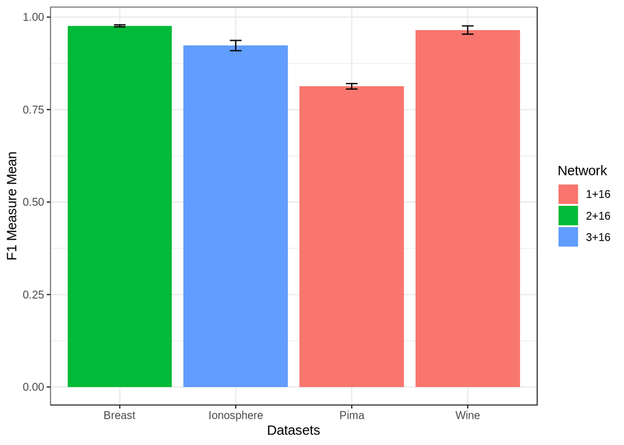

```r
beast_f1<- ggplot(total_dataset, aes(x= dataset, y =mean_f1, fill=as.factor(network))) +
geom_bar(stat = "identity", position = "dodge") +
  geom_errorbar(aes(ymin=mean_f1-f1_sd, ymax=mean_f1+f1_sd), width=.1) +
  labs(x ="Datasets", y = "F1 Measure Mean", fill = "Network") +
  theme_bw()

beast_f1
```

```r
png(filename="result/beast_f1.png", width = 600, height = 400)
plot(beast_f1)
dev.off()
```

Here! the plot the best f1 and config.